# T-TestTask1

## Loading and transforming the data

```matlab
data_table = readtable("datasets/DB01_gaming_video_quality_dataset.xlsx");
data_2000 = data_table((data_table.Bitrate == 2000)&(data_table.Game == "Game1") & (data_table.Condition ==36 | data_table.Condition == 50),{'PID','VQ'});
data_6000 = data_table((data_table.Bitrate == 6000)&(data_table.Game == "Game1") & (data_table.Condition ==36 | data_table.Condition == 50),{'PID','VQ'});
data_2000.Properties.VariableNames = {'PID', 'VQ_2000'};
data_6000.Properties.VariableNames = {'PID', 'VQ_6000'};
data_all = join(data_2000, data_6000)
```

```
data_all =

  25x3 table

    PID    VQ_2000    VQ_6000
    ___    _______    _______

     1       2.9        4.5
     2       4.6        5.7
     3       2.7        4.5
     4       2.6        3.5
     5       2.7        4.5
     6         3          5
     7         3        4.4
     8         2        4.1
```

[output cut: 17 more lines]

## Deciding on the statistical test that is going to be used and checking if the required conditions are met

Since the PIDs in both conditions are identical(same people rate the video quality), we use **dependent t-test**.

Checking if the conditions are met:

1. dependent variable should be measured at the interval or ratio level (i.e., continuous)
2. no significant outliers
3. independent variable should consist of two categorical, related groups
4. distribution of the differences in the dependent variable between the two related groups should be approximately normally distributed

#### Condition 1

We have Video Quality(VQ) as dependent variable and it is continuous. ✅

#### Condition 2

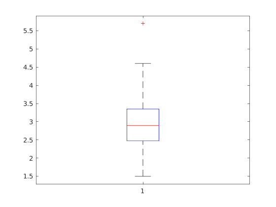

```matlab
boxplot(data_all.VQ_2000)
```

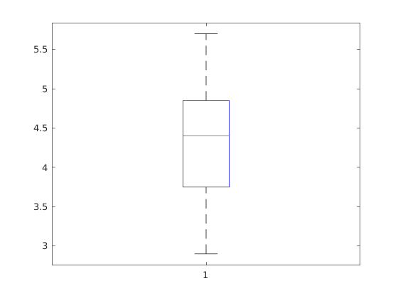

```matlab
boxplot(data_all.VQ_6000)
```

We remove the extreme outlier(PID = 13) from the dataset.✅

```matlab
data_all = data_all(data_all.PID ~=13,:)
```

```
data_all =

  24x3 table

    PID    VQ_2000    VQ_6000
    ___    _______    _______

     1       2.9        4.5
     2       4.6        5.7
     3       2.7        4.5
     4       2.6        3.5
     5       2.7        4.5
     6         3          5
     7         3        4.4
     8         2        4.1
```

[output cut: 16 more lines]

#### Condition 4

```matlab
data_all.Diff = data_all.VQ_6000 - data_all.VQ_2000
```

```
data_all =

  24x4 table

    PID    VQ_2000    VQ_6000    Diff
    ___    _______    _______    ____

     1       2.9        4.5       1.6
     2       4.6        5.7       1.1
     3       2.7        4.5       1.8
     4       2.6        3.5       0.9
     5       2.7        4.5       1.8
     6         3          5         2
     7         3        4.4       1.4
     8         2        4.1       2.1
```

[output cut: 16 more lines]

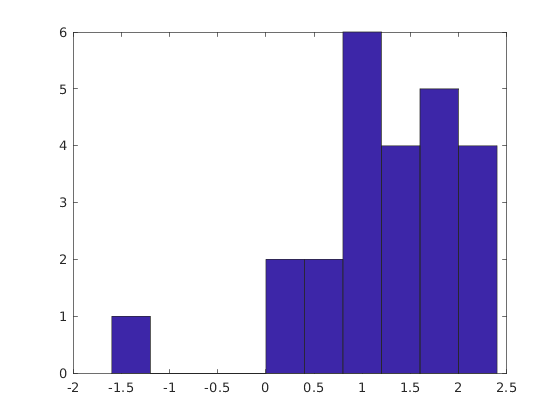

```matlab
hist(data_all.Diff)
```

```matlab
[h,p,ci,stats] = ttest(data_all.VQ_2000, data_all.VQ_6000)
```

```
h =

     1


p =

   5.5802e-07


ci =

   -1.5898
   -0.8519


stats =

  struct with fields:

    tstat: -6.8449
       df: 23
       sd: 0.8738
```

The null hypothesis in general claims that the pairwise difference between data vectors x and y has a mean equal to zero. h is equal to 1 and p is a very low being 5.5802e-07(tstat is equal to -6.8449 with 23 degrees of freedom), we can reject the null hypothesis at a 5% significance level. => Increasing bitrate significantly improves the VQ ratings.

#### Effect Size - Cohen's d

```matlab
m1 = mean(data_all.VQ_2000);
m2 = mean(data_all.VQ_6000);
sd1 = std(data_all.VQ_2000);
sd2 = std(data_all.VQ_6000);

cohen_d = (m2-m1) / (sqrt((sd1 + sd2)/2))
```

```
cohen_d =

    1.3216
```

The difference in VQ ratings between both conditions(2000 vs 6000) represents a large sized effect. (cohen_d > 0.8)